# Fort Worth Climate Change

# Visualizing Temperature

Visualizing temperature offered a lot of flexibility in terms of design. A graphic design that I favored was the density ridge graphs. Here, we can see the range of temperature for each month and the breakdown of one annual year in Texas. The colors are coordinated to match the colder or warmer temperatures presented throughout the year.

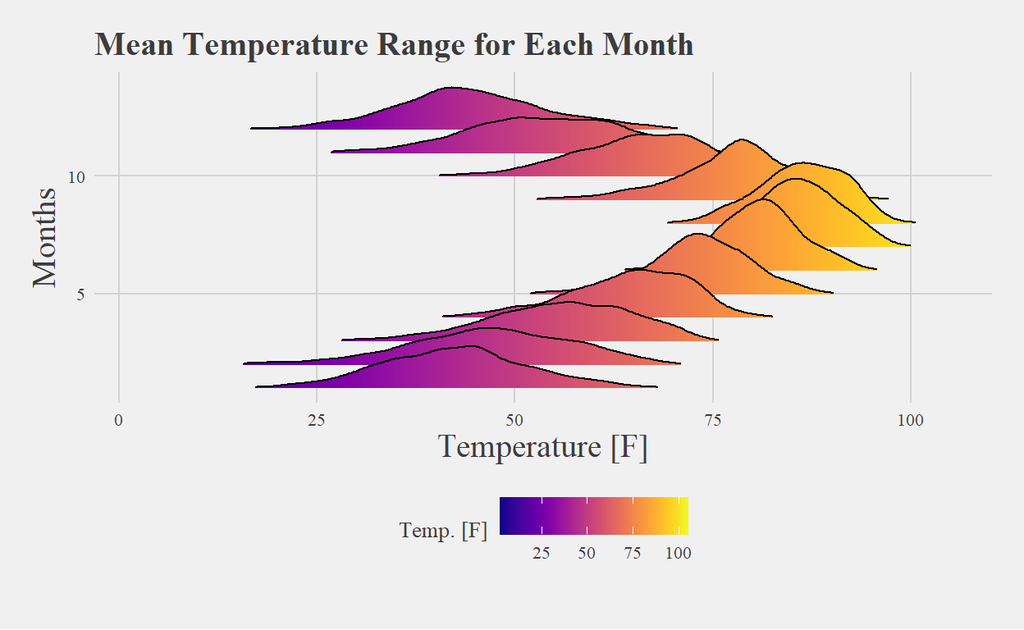

```r
Temperature_Final %>%
ggplot(mapping = aes(x = Temperature, y = MO, group = MO, fill = ..x..)) +
geom_density_ridges_gradient(scale = 3, rel_min_height = 0.01,
alpha = 5) +
scale_fill_viridis(name = "Temp. [F]", option = "C") +
theme_fivethirtyeight(base_size = 10, base_family = 'serif') +
  theme(axis.title = element_text(family = 'serif', size = 15)) + ylab('Months') + xlab('Temperature [F]') +
  labs(title = "Mean Temperature Range for Each Month", caption = "")
```

Below is the percent changed function based on the comparison from 1981 to each subsequent year. The major conclusion to be made when analyzing this section is the difference between 1981 and 2022. There is an increase of 1.78% which shows a change within the climate; however, this is not a significant amount of change in the broader understanding of climate.

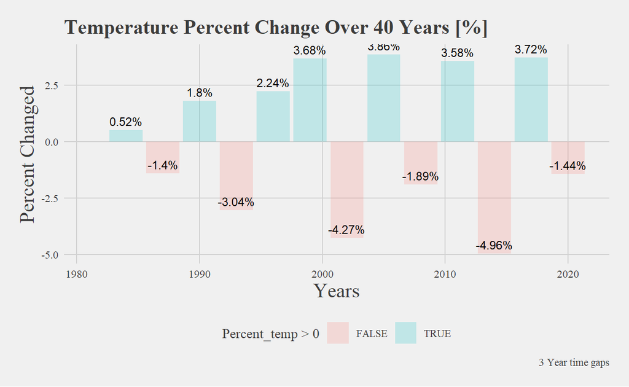

```r
ggplot(data = Temp_change) +
  geom_col(aes(x = YEAR, y = Percent_temp, fill = Percent_temp > 0), alpha = .2) +
  geom_text(aes(x = YEAR, y = Percent_temp, label = paste0(round(Percent_temp,2), "%")),size = 3, vjust = -.5) +
   theme_fivethirtyeight(base_size = 10, base_family = 'serif') +
  theme(axis.title = element_text(family = 'serif', size = 15)) + ylab('Percent Changed') + xlab('Years') +
  labs(title = "Temperature Percent Change Over 40 Years [%]", caption = "3 Year time gaps")
```

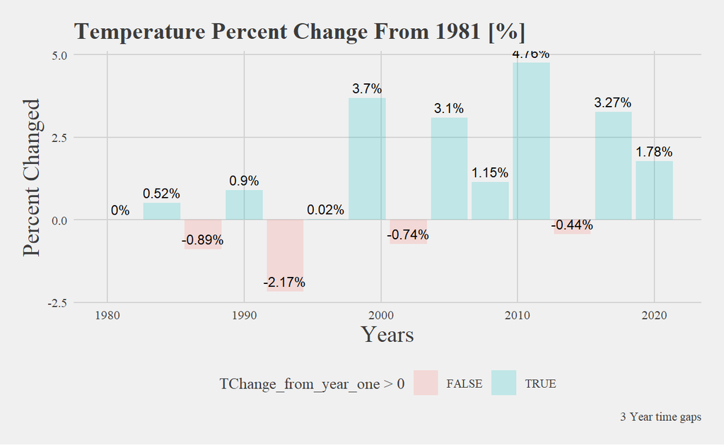

```r
ggplot(data = Temp_change) +
  geom_col(aes(x = YEAR, y = TChange_from_year_one, fill = TChange_from_year_one > 0), alpha = .2) +
  geom_text(aes(x = YEAR, y = TChange_from_year_one, label =  paste0(round(TChange_from_year_one,2), "%")),size = 3, vjust = -.5) +
  theme_fivethirtyeight(base_size = 10, base_family = 'serif') +
  theme(axis.title = element_text(family = 'serif', size = 15)) + ylab('Percent Changed') + xlab('Years') +
  labs(title = "Temperature Percent Change From 1981 [%]", caption = "3 Year time gaps")
```

## Visualizing Precipitation

The percent change difference from 1981 to each subsequent year is visualized above. We notice that there has been a major decrease in precipitation since 1981 excluding 1990. To the modern-day, a 13.48% decrease has occurred resulting in a major shift in precipitation. Based on the mean precipitation the annual amount would be 34.92 inches. Utilizing this number, the -13.48% would decrease precipitation by 4.7 inches annually. This number displays a major shift in precipitation and could cause a decrease in vegetation or wildlife within the local environment. This is one major discovery that was unexpected as recent events within the state have suggested the opposite of this statistic. The most recent decade appears to be progressing towards a positive number, future analysis will be able to confirm if there is an increase in precipitation coming.

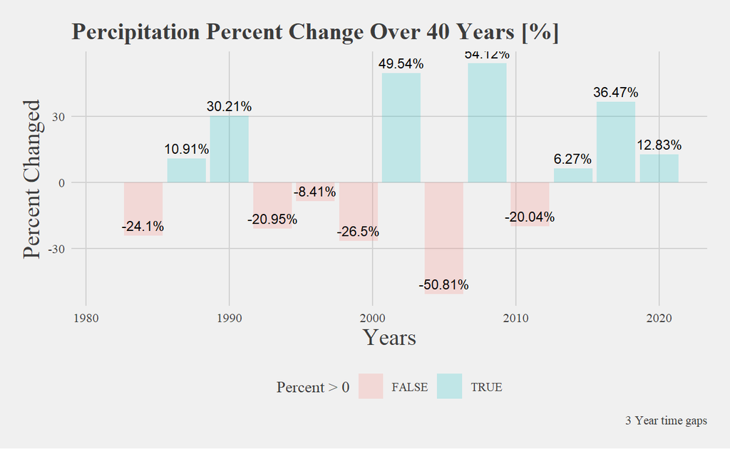

```r
ggplot(data = Pct_change) +
  geom_col(aes(x = YEAR, y = Percent, fill = Percent > 0), alpha = .2) +
  theme_classic() +
  geom_text(aes(x = YEAR, y = Percent, label = paste0(round(Percent,2), "%")),size = 3, vjust = -.5) +
      theme_fivethirtyeight(base_size = 10, base_family = 'serif') +
  theme(axis.title = element_text(family = 'serif', size = 15)) + ylab('Percent Changed') + xlab('Years') +
  labs(title = "Percipitation Percent Change Over 40 Years [%]", caption = "3 Year time gaps")
```

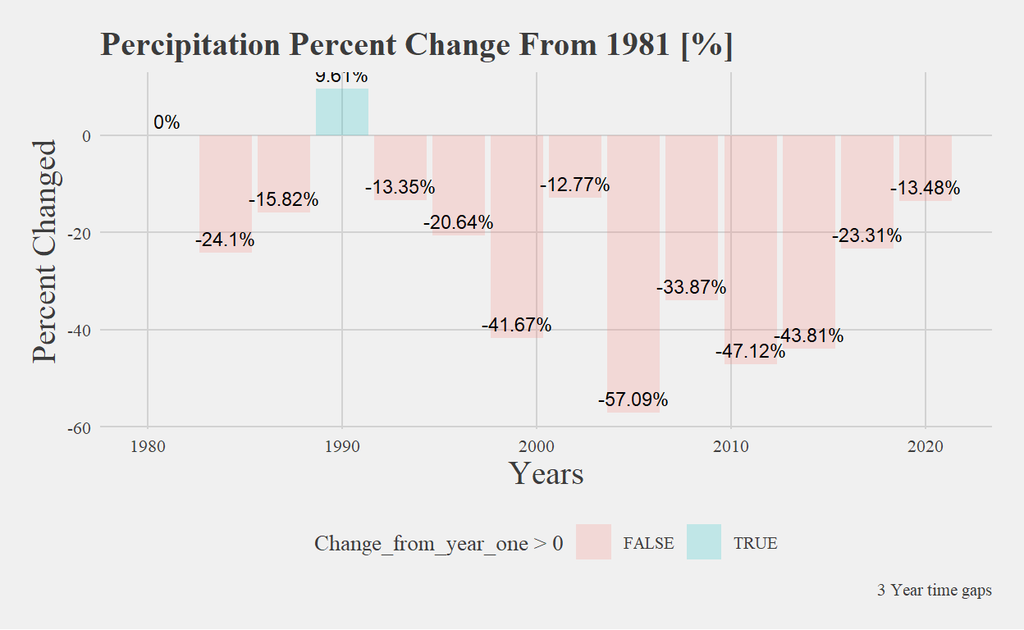

```r
ggplot(data = Pct_change) +
 geom_col(aes(x = YEAR, y = Change_from_year_one, fill = Change_from_year_one > 0), alpha = .2) +
  theme_classic() +
  geom_text(aes(x = YEAR, y = Change_from_year_one, label = paste0(round(Change_from_year_one,2), "%")),size = 3, vjust = -.5) +
      theme_fivethirtyeight(base_size = 10, base_family = 'serif') +
  theme(axis.title = element_text(family = 'serif', size = 15)) + ylab('Percent Changed') + xlab('Years') +
  labs(title = "Percipitation Percent Change From 1981 [%]", caption = "3 Year time gaps")
```

## Visualizing Humidity

Humidity percent change compared to the original year has followed a similar suit to precipitation which is within the range of expectation as the correlation between these two variables is high. However, one interesting fact is that when looking at the modern-day number we notice only a slight decrease compared to 1981. There seems to be an increase in water vapor over the last decade indicating that within the next few years there may be a larger amount of humidity.

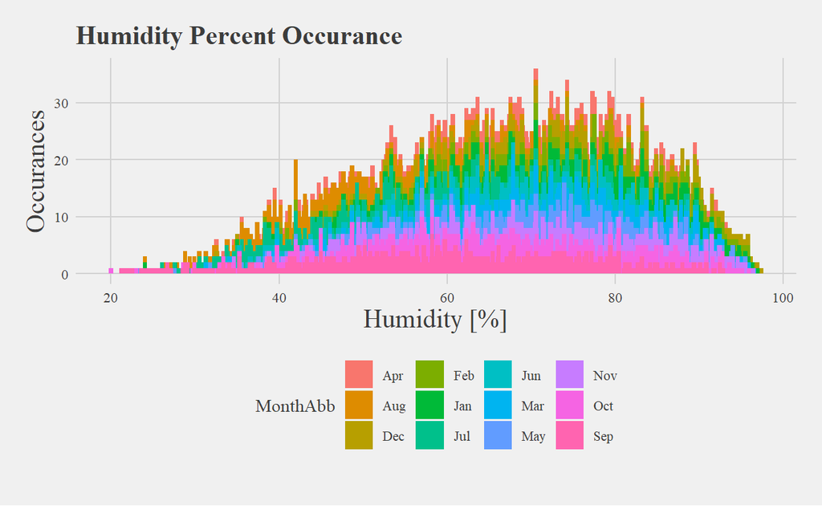

```r
ggplot(data = Humidity_Final, mapping = aes(x = Humidity)) +
  geom_bar(mapping = aes(fill = MonthAbb), width = .5) +
    guides(
    color = guide_colorbar(
      nrow = 1,
      override.aes = list(size = 4)
    )
  ) +
  theme_fivethirtyeight(base_size = 10, base_family = 'serif') +
  theme(axis.title = element_text(family = 'serif', size = 15)) + ylab('Occurances') + xlab('Humidity [%]') +
  labs(title = "Humidity Percent Occurance", caption = "")
```

[figure not shown]

```r
ggplot(data = HPct_change) +
  geom_col(aes(x = YEAR, y = HPercent, fill = HPercent > 0), alpha = .2) +
  geom_text(aes(x = YEAR, y = HPercent, label = paste0(round(HPercent,2), "%")),size = 3, vjust = -.5) +
    theme_fivethirtyeight(base_size = 10, base_family = 'serif') +
  theme(axis.title = element_text(family = 'serif', size = 15)) + ylab('Percent Changed') + xlab('Years') +
  labs(title = "Humidity Percent Change From 1981 [%]", caption = "3 Year time gaps")
```

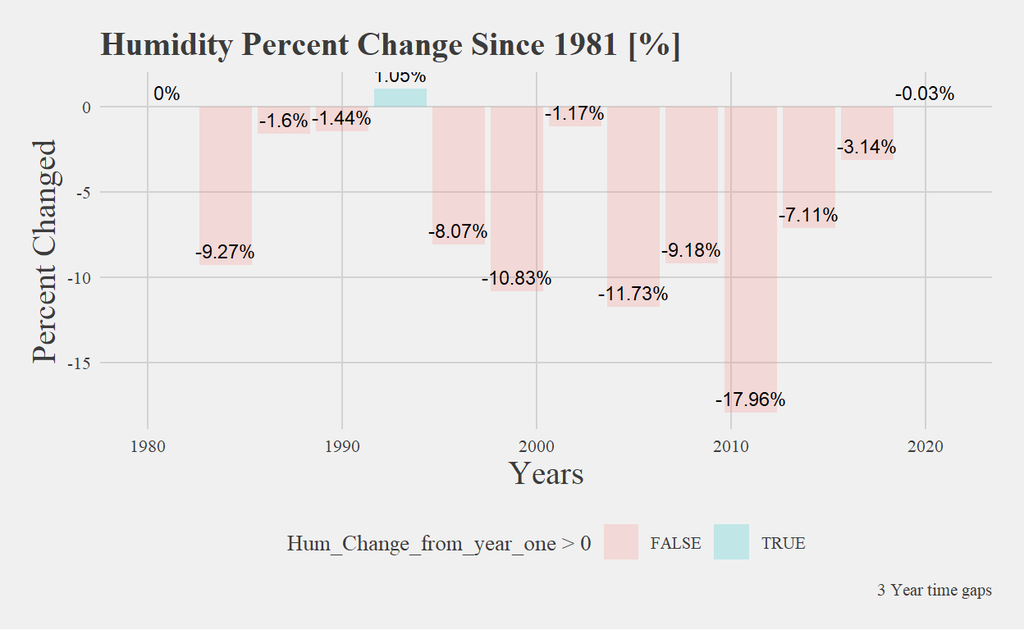

```r
ggplot(data = HPct_change) +
  geom_col(aes(x = YEAR, y = Hum_Change_from_year_one, fill = Hum_Change_from_year_one > 0), alpha = .2) +
  geom_text(aes(x = YEAR, y = Hum_Change_from_year_one, label = paste0(round(Hum_Change_from_year_one,2), "%")),size = 3, vjust = -.5) +
  theme_fivethirtyeight(base_size = 10, base_family = 'serif') +
  theme(axis.title = element_text(family = 'serif', size = 15)) + ylab('Percent Changed') + xlab('Years') +
  labs(title = "Humidity Percent Change Since 1981 [%]", caption = "3 Year time gaps")
```

# Reflection

Upon reflection of this project, an exuberant amount of information was absorbed during this analytical process. Being new to R and analytics, a significant amount of study was applied to learn the analytical process as well as the functions in play. There was a steep learning period presented by unique problems requiring out of box thinking. Learning through trial and error was extremely useful as it forced me to be hands-on with the information and think through each situation. The general workflow for this process is as follows: run initial code, encounter an error, review error and code, if fixable, then changes were applied, if not, then search for answers, apply those changes, and test. This taught me to think through a problem and identify the major changes required. This adaptability taught me critical professional skills I expect to apply to my future career. For this project, I wanted to approach the question of climate change on a micro level within the Fort Worth area of Texas. The urge stemmed from recent abnormal local weather occurrences. To note a few, in 2015 a major drought plagued the local area resulting in an arid environment. In continuation, a season of high precipitation occurred resulting in flooding and damage to properties. Additionally, the winter storm of 2021 which shut the majority of Texas down for 5 days inspired me to investigate my own community closer. This project was extremely helpful in relation to my growth as an analyst as it forced me to handle the entire analytical process while also allowing me to explore my interests.

Data analysis is ongoing for this data set. Future analysis would include the other values such as wind speed and surface pressure to enable a deeper statistical evaluation. Additionally, I would like to import a dataset that dates back further to increase the accuracy of my information and conclusion. These tools would permit me to create a continuously updating system that provides more accurate information with each passing day for Fort Worth, Texas.

# Conclusion: Has the climate changed?

Based on the results of this analysis, there has not been a major shift in climate within Fort Worth, Texas. The reason for these claims is the lack of significant increase or decrease over time compared to 1981. There were years where a major shift in the variable would occur; however, that was corrected out by the following year and can be attributed to expected variations within the Fort Worth subtropical climate. Some interesting takeaways from this project were that both the precipitation and humidity graphs were indicating a trend of growth. Each of these variables were negative compared to 1981. However, they increased rapidly over the last decade indicating that there could be a possible increase in both precipitation and humidity. Temperature proved to be inconsistent and happened to be on the higher side during this current segment; this is expected to decrease once more. There were some questions that remain to be answered from this analysis. A major question that remains is the lack of wind and surface pressure and what effects those variables would play in determining the overarching shift in climate change. The second question is more of a limiting factor which is the lack of time incorporated into this study. Roughly 40 years were dated within this analysis; however, more historical data would have highlighted major shifts in variables. With these major shifts, we could have located more trends or patterns within this study. The third and final aspect that could have provided a more in-depth analysis is more variance in statistical data. Most statistics used within this study were descriptive revolving around the central tendency. However, incorporating Bayesian statistics would have enabled a more precise analysis. These factors highlight the need for further research and analysis. However, with current information and statistics based on this data set, we can say that there is not a major shift in climate change within the last 40 years.

# Bibliography

- NASA. Overview: Weather, Global Warming, and Climate Change. 2022. 17 April 2022. https://climate.nasa.gov/resources/global-warming-vs-climate-change/.
- R Core Team (2021). R: A language and environment for statistical computing. R Foundation for Statistical Computing, Vienna, Austria. URL https://www.R-project.org/.
- Research, NASA Langley. The POWER Project. 08 May 2021. 21 February 2022. https://power.larc.nasa.gov..
  - (“These data were obtained from the NASA Langley Research Center (LaRC) POWER Project funded through the NASA Earth Science/Applied Science Program.”)
- Wickham, Hadley and Garrett Grolemund. R for Data Science. O’REILLY, 2017. https://r4ds.had.co.nz.